# Breast Cancer RNA-seq Analysis

S3490964_PRANSHU_JIVNANI

2026-03-12

```r
knitr::opts_chunk$set(echo = TRUE)

library(TCGAbiolinks)
library(SummarizedExperiment)
library(dplyr)
library(ggplot2)
```

# Query TCGA-BRCA data

We query TCGA-BRCA RNA-seq count data for primary tumor and normal breast tissue samples.

```r
query <- GDCquery(
  project = "TCGA-BRCA",
  data.category = "Transcriptome Profiling",
  data.type = "Gene Expression Quantification",
  workflow.type = "STAR - Counts",
  sample.type = c("Primary Tumor", "Solid Tissue Normal")
)
```

```
## o GDCquery: Searching in GDC database
```

```
## Genome of reference: hg38
```

```
## oo Accessing GDC. This might take a while...
```

```
## ooo Project: TCGA-BRCA
```

```
## oo Filtering results
```

```
## ooo By data.type
```

```
## ooo By workflow.type
```

```
## ooo By sample.type
```

```
## oo Checking data
```

```
## ooo Checking if there are duplicated cases
```

```
## ooo Checking if there are results for the query
```

```
## o Preparing output
```

```r
query
```

```
##        results   project           data.category                      data.type
## 1 c("744a6.... TCGA-BRCA Transcriptome Profiling Gene Expression Quantification
##   access experimental.strategy platform  sample.type barcode workflow.type
## 1     NA                    NA       NA Primary ....      NA STAR - Counts
```

# Download TCGA-BRCA data

We now download the TCGA-BRCA RNA-seq files returned by the query into the raw data folder of the project.

```r
GDCdownload(
  query = query,
  method = "api",
  directory = "data_raw",
  files.per.chunk = 20
)
```

```
## Of the 1224 files for download 1224 already exist.
```

```
## All samples have been already downloaded
```

# Check downloaded files

Before preparing the TCGA object, we verify that files were downloaded into the raw data folder.

```r
list.files("data_raw", recursive = TRUE)[1:20]
```

```
##  [1] "TCGA-BRCA/Transcriptome_Profiling/Gene_Expression_Quantification/0019c951-16c5-48d0-85c8-58d96b12d330/ba295155-272e-43eb-9d6a-e4c9c392e68b.rna_seq.augmented_star_gene_counts.tsv"
##  [2] "TCGA-BRCA/Transcriptome_Profiling/Gene_Expression_Quantification/0022cd20-f64f-4773-b9ff-a3de0b71b259/8d1641ea-7552-4d23-9298-094e0056386a.rna_seq.augmented_star_gene_counts.tsv"
##  [3] "TCGA-BRCA/Transcriptome_Profiling/Gene_Expression_Quantification/00469928-b243-4cae-acd7-134508e99ceb/2f51534b-248b-4999-bc3f-e42a2e98332e.rna_seq.augmented_star_gene_counts.tsv"
##  [4] "TCGA-BRCA/Transcriptome_Profiling/Gene_Expression_Quantification/0081f507-b104-4214-9ea1-31dd69130991/b321a3f5-043d-42c6-8c9d-5784d45cb85c.rna_seq.augmented_star_gene_counts.tsv"
##  [5] "TCGA-BRCA/Transcriptome_Profiling/Gene_Expression_Quantification/0094f9d0-45ec-4aad-bca0-71c60bdd7113/cafc9e36-c5f0-45df-ad03-16210ff0d870.rna_seq.augmented_star_gene_counts.tsv"
##  [6] "TCGA-BRCA/Transcriptome_Profiling/Gene_Expression_Quantification/00b13ccf-ad7c-4613-8366-7c583a399691/c763a483-415e-4cb4-9cdf-4e6c31e8a9c9.rna_seq.augmented_star_gene_counts.tsv"
##  [7] "TCGA-BRCA/Transcriptome_Profiling/Gene_Expression_Quantification/010e405c-b91d-4046-898e-105d5830d9a9/7135f14b-e84f-4ebf-8d95-b2a3c843fd4d.rna_seq.augmented_star_gene_counts.tsv"
##  [8] "TCGA-BRCA/Transcriptome_Profiling/Gene_Expression_Quantification/017d71aa-0999-4d8e-9cb4-88b9013e61eb/c6683fc6-49f4-4e53-94ac-251799c2c638.rna_seq.augmented_star_gene_counts.tsv"
##  [9] "TCGA-BRCA/Transcriptome_Profiling/Gene_Expression_Quantification/02a0b95f-ea0f-4c0d-ba2d-9724ed9ad712/5fd42405-ebfe-4210-bc2f-d8310e3e14ee.rna_seq.augmented_star_gene_counts.tsv"
## [10] "TCGA-BRCA/Transcriptome_Profiling/Gene_Expression_Quantification/02a11397-2a9b-4dba-8c6a-6b9f0aa24372/9ccd787f-fde1-4fe6-a11f-d6203eaf9faf.rna_seq.augmented_star_gene_counts.tsv"
## [11] "TCGA-BRCA/Transcriptome_Profiling/Gene_Expression_Quantification/02e08315-4d34-421c-acc0-129b1e1de38b/4a88d54f-c88c-4ffd-84c9-069b53f2cb28.rna_seq.augmented_star_gene_counts.tsv"
## [12] "TCGA-BRCA/Transcriptome_Profiling/Gene_Expression_Quantification/03891509-3109-450d-8564-77b024a6128e/75668632-f0c7-495b-ba34-cd4b00aa9450.rna_seq.augmented_star_gene_counts.tsv"
## [13] "TCGA-BRCA/Transcriptome_Profiling/Gene_Expression_Quantification/03a1a105-4856-4e5c-b537-508bdbda50b5/02bbe1b1-44ff-426b-a40e-47a01bc4cf7d.rna_seq.augmented_star_gene_counts.tsv"
## [14] "TCGA-BRCA/Transcriptome_Profiling/Gene_Expression_Quantification/03d18286-1038-4c0c-9c05-d1269e280250/8bfd50fb-d6d8-44cd-a492-1e0a983e40b6.rna_seq.augmented_star_gene_counts.tsv"
## [15] "TCGA-BRCA/Transcriptome_Profiling/Gene_Expression_Quantification/04024f75-7405-4ccc-8976-91d0a3035b3a/e6f4bdc7-ab3f-4a62-aa6d-5223b25bbc89.rna_seq.augmented_star_gene_counts.tsv"
## [16] "TCGA-BRCA/Transcriptome_Profiling/Gene_Expression_Quantification/040d00da-2bc9-49d4-bf6c-b4515b6a2bbf/d4f91697-1c39-4398-bf2f-85217a22ddff.rna_seq.augmented_star_gene_counts.tsv"
## [17] "TCGA-BRCA/Transcriptome_Profiling/Gene_Expression_Quantification/0427af63-b665-4c57-874b-65222c200bfe/99296d22-e605-49cd-b37f-a1b900be5d53.rna_seq.augmented_star_gene_counts.tsv"
## [18] "TCGA-BRCA/Transcriptome_Profiling/Gene_Expression_Quantification/0437af11-bb89-4901-9764-bb410c2e94c5/5a61d29b-5ae6-41b6-8842-865463f72990.rna_seq.augmented_star_gene_counts.tsv"
## [19] "TCGA-BRCA/Transcriptome_Profiling/Gene_Expression_Quantification/046fe29e-7c99-4093-8565-f2f205a00796/61f811cf-9dc1-4f48-ad62-c3ebfd1f0847.rna_seq.augmented_star_gene_counts.tsv"
## [20] "TCGA-BRCA/Transcriptome_Profiling/Gene_Expression_Quantification/04a7cce8-c3b3-4994-9dac-c0e53099f37d/676cce88-9f6e-4490-8e73-c0e88bd00075.rna_seq.augmented_star_gene_counts.tsv"
```

```r
length(list.files("data_raw", recursive = TRUE))
```

```
## [1] 1224
```

```r
list.files("data_raw", pattern = "\\.tar\\.gz$", recursive = TRUE)
```

```
## character(0)
```

# Prepare TCGA-BRCA expression object

We now convert the downloaded TCGA files into a single R object containing gene expression data and sample metadata.

```r
brca_se <- GDCprepare(
  query = query,
  directory = "data_raw"
)
```

```
## Starting to add information to samples
```

```
##  => Add clinical information to samples
```

```
##  => Adding TCGA molecular information from marker papers
```

```
##  => Information will have prefix 'paper_'
```

```
## brca subtype information from:doi.org/10.1016/j.ccell.2018.03.014
```

```
## Available assays in SummarizedExperiment :
##   => unstranded
##   => stranded_first
##   => stranded_second
##   => tpm_unstrand
##   => fpkm_unstrand
##   => fpkm_uq_unstrand
```

```r
brca_se
```

```
## class: RangedSummarizedExperiment
## dim: 60660 1224
## metadata(1): data_release
## assays(6): unstranded stranded_first ... fpkm_unstrand fpkm_uq_unstrand
## rownames(60660): ENSG00000000003.15 ENSG00000000005.6 ...
##   ENSG00000288674.1 ENSG00000288675.1
## rowData names(10): source type ... hgnc_id havana_gene
## colnames(1224): TCGA-BH-A18H-01A-11R-A12D-07
##   TCGA-E2-A14P-01A-31R-A12D-07 ... TCGA-D8-A1JE-01A-11R-A13Q-07
##   TCGA-GM-A3XL-01A-11R-A22U-07
## colData names(94): barcode patient ... paper_PARADIGM Clusters
##   paper_Pan-Gyn Clusters
```

# Save processed TCGA object

We save the processed TCGA-BRCA object so it can be reused without repeating the download step.

```r
saveRDS(brca_se, file = "../data_processed/brca_se.rds")
```

# Check sample groups

We now inspect the sample metadata to confirm the number of tumor and normal samples in the TCGA-BRCA dataset.

```r
table(brca_se$shortLetterCode)
```

```
##
##   NT   TP
##  113 1111
```

# Extract expression matrix and metadata

We now extract the raw count matrix and the sample metadata from the TCGA-BRCA object for downstream analysis.

```r
count_matrix <- assay(brca_se, "unstranded")
sample_metadata <- as.data.frame(colData(brca_se))

dim(count_matrix)
```

```
## [1] 60660  1224
```

```r
dim(sample_metadata)
```

```
## [1] 1224   94
```

# Confirm sample order

We verify that the sample names in the count matrix match the sample names in the metadata table.

```r
identical(colnames(count_matrix), rownames(sample_metadata))
```

```
## [1] TRUE
```

# Create analysis group labels

We create a simple analysis group variable that labels samples as Tumor or Normal for downstream comparison.

```r
sample_metadata$group <- ifelse(sample_metadata$shortLetterCode == "TP", "Tumor", "Normal")

table(sample_metadata$group)
```

```
##
## Normal  Tumor
##    113   1111
```

# Filter low-count genes

We remove genes with very low counts across samples, because such genes usually add noise and are not informative for differential expression analysis.

```r
keep_genes <- rowSums(count_matrix >= 10) >= 10
filtered_counts <- count_matrix[keep_genes, ]

dim(count_matrix)
```

```
## [1] 60660  1224
```

```r
dim(filtered_counts)
```

```
## [1] 37589  1224
```

# Save filtered data

We save the filtered count matrix and the sample metadata so that the project can be resumed without repeating earlier processing steps.

```r
saveRDS(filtered_counts, file = "../data_processed/filtered_counts.rds")
saveRDS(sample_metadata, file = "../data_processed/sample_metadata.rds")
```

# Create DESeq2 dataset

We now create a DESeq2 dataset object using the filtered count matrix and the tumor-versus-normal group labels. This object will be used for differential expression analysis.

```r
library(DESeq2)

dds <- DESeqDataSetFromMatrix(
  countData = filtered_counts,
  colData = sample_metadata,
  design = ~ group
)
dds
```

```
## class: DESeqDataSet
## dim: 37589 1224
## metadata(1): version
## assays(1): counts
## rownames(37589): ENSG00000000003.15 ENSG00000000005.6 ...
##   ENSG00000288674.1 ENSG00000288675.1
## rowData names(0):
## colnames(1224): TCGA-BH-A18H-01A-11R-A12D-07
##   TCGA-E2-A14P-01A-31R-A12D-07 ... TCGA-D8-A1JE-01A-11R-A13Q-07
##   TCGA-GM-A3XL-01A-11R-A22U-07
## colData names(95): barcode patient ... paper_Pan.Gyn.Clusters group
```

# Run DESeq2 analysis

We now run the DESeq2 workflow to estimate size factors, normalize counts, and fit the statistical model for differential expression between tumor and normal samples.

```r
dds <- DESeq(dds)
```

```
## -- replacing outliers and refitting for 7888 genes
## -- DESeq argument 'minReplicatesForReplace' = 7
## -- original counts are preserved in counts(dds)
```

# Extract differential expression results

We now extract the differential expression results from DESeq2 to identify genes that differ between tumor and normal breast tissue.

```r
res <- results(dds, contrast = c("group", "Tumor", "Normal"))
res
```

```
## log2 fold change (MLE): group Tumor vs Normal
## Wald test p-value: group Tumor vs Normal
## DataFrame with 37589 rows and 6 columns
##                      baseMean log2FoldChange     lfcSE      stat      pvalue
##                     <numeric>      <numeric> <numeric> <numeric>   <numeric>
## ENSG00000000003.15   3104.122      -0.602007 0.0920060  -6.54313 6.02442e-11
## ENSG00000000005.6     154.206      -3.490144 0.2520997 -13.84430 1.37715e-43
## ENSG00000000419.13   2303.076       0.451662 0.0557918   8.09549 5.70329e-16
## ENSG00000000457.14   1566.265       0.388862 0.0563695   6.89845 5.25720e-12
## ENSG00000000460.17    694.215       1.328730 0.0755047  17.59798 2.55263e-69
## ...                       ...            ...       ...       ...         ...
## ENSG00000288663.1   29.171892      0.2662731 0.0877850   3.03324 2.41943e-03
## ENSG00000288667.1    0.915114      1.5361534 0.7239490   2.12191 3.38454e-02
## ENSG00000288670.1  421.413319     -0.0693548 0.0674680  -1.02796 3.03966e-01
## ENSG00000288674.1    8.276956     -0.5294752 0.0936355  -5.65464 1.56171e-08
## ENSG00000288675.1   31.422985      1.4257828 0.1090355  13.07631 4.49725e-39
##                           padj
##                      <numeric>
## ENSG00000000003.15 1.90648e-10
## ENSG00000000005.6  1.90384e-42
## ENSG00000000419.13 2.43090e-15
## ENSG00000000457.14 1.78480e-11
## ENSG00000000460.17 7.95613e-68
## ...                        ...
## ENSG00000288663.1  3.89015e-03
## ENSG00000288667.1  4.64550e-02
## ENSG00000288670.1  3.50646e-01
## ENSG00000288674.1  4.16601e-08
## ENSG00000288675.1  5.30927e-38
```

# Identify significant genes

We count genes that show significant differential expression between tumor and normal tissue.

```r
sig_genes <- res[which(res$padj < 0.05), ]

nrow(sig_genes)
```

```
## [1] 27552
```

# Apply a stricter significance filter

We now apply a stricter filter to identify genes that are not only statistically significant but also show a meaningful change in expression between tumor and normal tissue.

```r
sig_genes_strict <- res[which(res$padj < 0.05 & abs(res$log2FoldChange) > 1), ]

nrow(sig_genes_strict)
```

```
## [1] 11462
```

# Save differential expression results

We save the full differential expression results and the stricter significant gene set for later interpretation and visualization.

```r
res_df <- as.data.frame(res)
sig_genes_strict_df <- as.data.frame(sig_genes_strict)

write.csv(res_df, file = "../results/deseq2_results_full.csv")
write.csv(sig_genes_strict_df, file = "../results/deseq2_results_strict.csv")
```

# Volcano plot

We create a volcano plot to visualize which genes are significantly upregulated or downregulated between tumor and normal breast tissue.

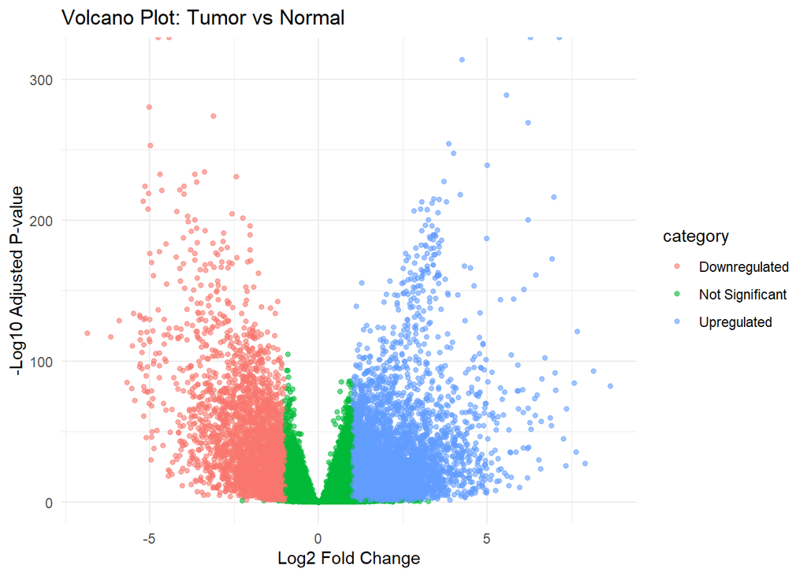

```r
volcano_df <- as.data.frame(res)
volcano_df$gene <- rownames(volcano_df)

volcano_df$category <- "Not Significant"
volcano_df$category[volcano_df$padj < 0.05 & volcano_df$log2FoldChange > 1] <- "Upregulated"
volcano_df$category[volcano_df$padj < 0.05 & volcano_df$log2FoldChange < -1] <- "Downregulated"

ggplot(volcano_df, aes(x = log2FoldChange, y = -log10(padj), color = category)) +
  geom_point(alpha = 0.6, size = 1.2) +
  theme_minimal() +
  labs(
    title = "Volcano Plot: Tumor vs Normal",
    x = "Log2 Fold Change",
    y = "-Log10 Adjusted P-value"
  )
```

# Save volcano plot

We save the volcano plot for inclusion in the final report.

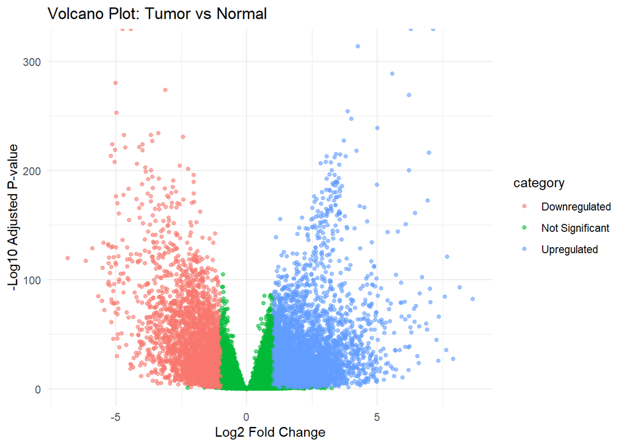

```r
volcano_df <- as.data.frame(res)
volcano_df$gene <- rownames(volcano_df)
volcano_df <- volcano_df[!is.na(volcano_df$padj), ]

volcano_df$category <- "Not Significant"
volcano_df$category[volcano_df$padj < 0.05 & volcano_df$log2FoldChange > 1] <- "Upregulated"
volcano_df$category[volcano_df$padj < 0.05 & volcano_df$log2FoldChange < -1] <- "Downregulated"

p <- ggplot(volcano_df, aes(x = log2FoldChange, y = -log10(padj), color = category)) +
  geom_point(alpha = 0.6, size = 1.2) +
  theme_minimal() +
  labs(
    title = "Volcano Plot: Tumor vs Normal",
    x = "Log2 Fold Change",
    y = "-Log10 Adjusted P-value"
  )

print(p)
```

```r
ggsave(
  filename = "../figures/volcano_plot.png",
  plot = p,
  width = 8,
  height = 6,
  dpi = 300
)
```

# Top differentially expressed genes

We identify the top 20 most significant differentially expressed genes based on adjusted p-value.

```r
res_df <- as.data.frame(res)
res_df$gene_id <- rownames(res_df)

top20_genes <- res_df[order(res_df$padj), ][1:20, ]

top20_genes[, c("gene_id", "log2FoldChange", "padj")]
```

```
##                               gene_id log2FoldChange          padj
## ENSG00000099953.10 ENSG00000099953.10       6.278113  0.000000e+00
## ENSG00000101605.13 ENSG00000101605.13      -4.764316  0.000000e+00
## ENSG00000119927.14 ENSG00000119927.14      -4.430168  0.000000e+00
## ENSG00000123500.10 ENSG00000123500.10       7.128127  0.000000e+00
## ENSG00000117650.13 ENSG00000117650.13       4.253322 9.550025e-315
## ENSG00000230838.1   ENSG00000230838.1       5.560568 1.616786e-289
## ENSG00000022267.19 ENSG00000022267.19      -5.030832 4.488690e-281
## ENSG00000079308.19 ENSG00000079308.19      -3.110478 1.035418e-274
## ENSG00000060718.22 ENSG00000060718.22       6.200023 5.248676e-270
## ENSG00000090889.12 ENSG00000090889.12       3.852561 5.911667e-255
## ENSG00000133800.9   ENSG00000133800.9      -4.982605 8.428707e-254
## ENSG00000127564.17 ENSG00000127564.17       4.006196 2.637965e-248
## ENSG00000203805.11 ENSG00000203805.11       4.990778 7.055195e-240
## ENSG00000105974.13 ENSG00000105974.13      -3.388364 5.507675e-235
## ENSG00000134962.7   ENSG00000134962.7      -4.710503 2.313320e-233
## ENSG00000095637.22 ENSG00000095637.22      -3.669557 3.775773e-233
## ENSG00000170145.5   ENSG00000170145.5      -2.441992 2.105197e-231
## ENSG00000183856.11 ENSG00000183856.11       3.706322 4.270913e-228
## ENSG00000169418.10 ENSG00000169418.10      -3.614404 8.217893e-228
## ENSG00000173641.18 ENSG00000173641.18      -5.153658 5.988905e-225
```

# Inspect gene annotation columns

We inspect the gene annotation columns available in the TCGA object so that we can identify the correct column containing gene symbols.

```r
gene_info <- as.data.frame(rowData(brca_se))
colnames(gene_info)
```

```
##  [1] "source"      "type"        "score"       "phase"       "gene_id"
##  [6] "gene_type"   "gene_name"   "level"       "hgnc_id"     "havana_gene"
```

# Add gene symbols

We map Ensembl gene IDs to gene symbols using the gene_name column from the TCGA annotation data.

```r
gene_info_subset <- gene_info[, c("gene_id", "gene_name")]
colnames(gene_info_subset) <- c("gene_id", "gene_symbol")

top20_genes_annotated <- merge(top20_genes, gene_info_subset, by = "gene_id")

top20_genes_annotated[, c("gene_symbol", "log2FoldChange", "padj")]
```

```
##    gene_symbol log2FoldChange          padj
## 1         FHL1      -5.030832 4.488690e-281
## 2      COL11A1       6.200023 5.248676e-270
## 3         TNS1      -3.110478 1.035418e-274
## 4        KIF4A       3.852561 5.911667e-255
## 5       SORBS1      -3.669557 3.775773e-233
## 6        MMP11       6.278113  0.000000e+00
## 7        MYOM1      -4.764316  0.000000e+00
## 8         CAV1      -3.388364 5.507675e-235
## 9         NEK2       4.253322 9.550025e-315
## 10        GPAM      -4.430168  0.000000e+00
## 11     COL10A1       7.128127  0.000000e+00
## 12      PKMYT1       4.006196 2.637965e-248
## 13       LYVE1      -4.982605 8.428707e-254
## 14         KLB      -4.710503 2.313320e-233
## 15        NPR1      -3.614404 8.217893e-228
## 16        SIK2      -2.441992 2.105197e-231
## 17       HSPB7      -5.153658 5.988905e-225
## 18      IQGAP3       3.706322 4.270913e-228
## 19       PLPP4       4.990778 7.055195e-240
## 20   LINC01614       5.560568 1.616786e-289
```

# Save top annotated genes

We save the top 20 annotated differentially expressed genes for later interpretation and reporting.

```r
write.csv(
  top20_genes_annotated,
  file = "../results/top20_genes_annotated.csv",
  row.names = FALSE
)
```

# Top upregulated and downregulated genes

We separate the most strongly upregulated and downregulated genes to better interpret expression changes in breast cancer.

```r
top_upregulated <- res_df[order(-res_df$log2FoldChange), ][1:10, ]
top_downregulated <- res_df[order(res_df$log2FoldChange), ][1:10, ]

top_upregulated <- merge(top_upregulated, gene_info_subset, by = "gene_id")
top_downregulated <- merge(top_downregulated, gene_info_subset, by = "gene_id")

top_upregulated[, c("gene_symbol", "log2FoldChange", "padj")]
```

```
##    gene_symbol log2FoldChange          padj
## 1         CST4       7.661043 9.478596e-122
## 2      COL10A1       7.128127  0.000000e+00
## 3          CGA       8.136195  1.625714e-93
## 4       MAGEA6       7.891382  5.039822e-28
## 5       MAGEA1       7.256123  7.800822e-46
## 6         MUC2       7.581459  2.532943e-85
## 7        CSAG1       8.645607  3.264067e-83
## 8      MAGEA12       7.623623  2.466861e-36
## 9       MAGEA3       7.331655  2.331759e-26
## 10   LINC00052       7.342720  6.157612e-67
```

```r
top_downregulated[, c("gene_symbol", "log2FoldChange", "padj")]
```

```
##    gene_symbol log2FoldChange          padj
## 1         MYOC      -6.853791 1.677370e-120
## 2         APOB      -5.490672 1.144003e-134
## 3        GLYAT      -5.919344 1.595236e-129
## 4        PLIN1      -5.305564 1.748484e-133
## 5          CA4      -5.301893  8.406323e-97
## 6          LEP      -6.158207 7.324959e-118
## 7       AQP7P2      -5.442518  6.993331e-73
## 8    TRHDE-AS1      -5.529072 8.703071e-112
## 9   FP325317.1      -5.689929  7.696006e-86
## 10     LINCADL      -5.542707  1.495393e-81
```

# Save upregulated and downregulated genes

We save the top upregulated and downregulated genes identified from the differential expression analysis.

```r
write.csv(
  top_upregulated,
  file = "../results/top10_upregulated_genes.csv",
  row.names = FALSE
)

write.csv(
  top_downregulated,
  file = "../results/top10_downregulated_genes.csv",
  row.names = FALSE
)
```

# Pathway enrichment analysis

We now perform pathway enrichment analysis to identify biological processes associated with the differentially expressed genes in breast cancer.

```r
library(clusterProfiler)
library(org.Hs.eg.db)
```

# Prepare significant gene list for enrichment

We extract the significant genes and map them to gene symbols so that they can be used for pathway enrichment analysis.

```r
sig_genes_strict_df$gene_id <- rownames(sig_genes_strict_df)

sig_gene_symbols <- merge(
  sig_genes_strict_df,
  gene_info_subset,
  by = "gene_id"
)

sig_gene_symbols <- sig_gene_symbols$gene_symbol
sig_gene_symbols <- unique(sig_gene_symbols)

length(sig_gene_symbols)
```

```
## [1] 11406
```

```r
head(sig_gene_symbols)
```

```
## [1] "TNMD"     "C1orf112" "CFH"      "SEMA3F"   "MYH16"    "AOC1"
```

# Gene Ontology enrichment analysis

We perform Gene Ontology Biological Process enrichment analysis to identify biological processes overrepresented among the significantly differentially expressed genes in breast cancer.

```r
ego_bp <- enrichGO(
  gene = sig_gene_symbols,
  OrgDb = org.Hs.eg.db,
  keyType = "SYMBOL",
  ont = "BP",
  pAdjustMethod = "BH",
  pvalueCutoff = 0.05,
  qvalueCutoff = 0.05,
  readable = TRUE
)

head(as.data.frame(ego_bp))
```

```
##                    ID                                   Description GeneRatio
## GO:0042391 GO:0042391              regulation of membrane potential  203/4591
## GO:0006959 GO:0006959                       humoral immune response  137/4591
## GO:0019730 GO:0019730                antimicrobial humoral response   93/4591
## GO:0043062 GO:0043062          extracellular structure organization  143/4591
## GO:0045229 GO:0045229 external encapsulating structure organization  143/4591
## GO:0030198 GO:0030198             extracellular matrix organization  142/4591
##              BgRatio RichFactor FoldEnrichment   zScore       pvalue
## GO:0042391 474/18860  0.4282700       1.759349 9.497371 3.005441e-19
## GO:0006959 307/18860  0.4462541       1.833228 8.349153 4.093650e-15
## GO:0019730 184/18860  0.5054348       2.076345 8.322134 1.189745e-14
## GO:0043062 332/18860  0.4307229       1.769426 8.023017 3.475785e-14
## GO:0045229 333/18860  0.4294294       1.764112 7.979816 4.646534e-14
## GO:0030198 331/18860  0.4290030       1.762360 7.937150 6.266050e-14
##                p.adjust       qvalue
## GO:0042391 1.879002e-15 1.424263e-15
## GO:0006959 1.279675e-11 9.699796e-12
## GO:0019730 2.479428e-11 1.879379e-11
## GO:0043062 5.432652e-11 4.117891e-11
## GO:0045229 5.810026e-11 4.403936e-11
## GO:0030198 6.529224e-11 4.949080e-11
##                                                                                                                                                                                                                                                                                                          …
## GO:0042391 ABCB5/TAC1/CACNA1G/SCN4A/MAPK8IP2/DCN/GABRA3/ATP1A2/FHL1/GAB…
## GO:0006959                                                                                                                                                                                                                                                                                               …
## GO:0019730                                                                                                                                                                                                                                                                                               …
## GO:0043062                                                                                                                                                                                                                                                                                               …
## GO:0045229                                                                                                                                                                                                                                                                                               …
## GO:0030198                                                                                                                                                                                                                                                                                               …
##            Count
## GO:0042391   203
## GO:0006959   137
## GO:0019730    93
## GO:0043062   143
## GO:0045229   143
## GO:0030198   142
```

# Visualization of enriched biological processes

We visualize the top enriched Gene Ontology biological processes using a dot plot.

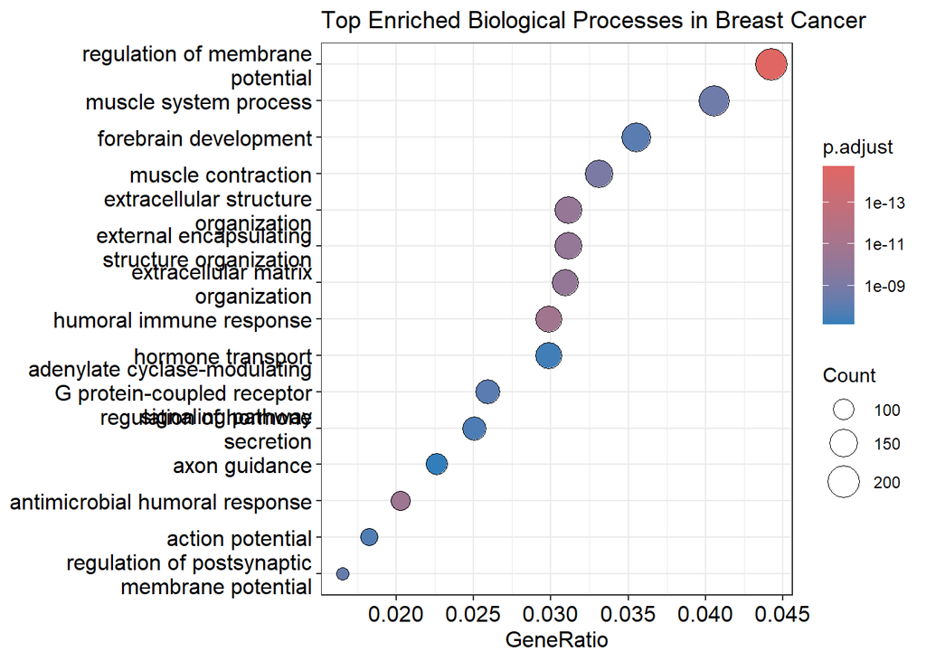

```r
dotplot(ego_bp, showCategory = 15) +
  ggtitle("Top Enriched Biological Processes in Breast Cancer")
```

# Principal Component Analysis (PCA)

We perform principal component analysis to visualize overall variation in the dataset and assess whether tumor and normal samples separate based on their expression profiles.

```r
vsd <- vst(dds, blind = FALSE)

pca_data <- plotPCA(vsd, intgroup = "group", returnData = TRUE)
```

```
## using ntop=500 top features by variance
```

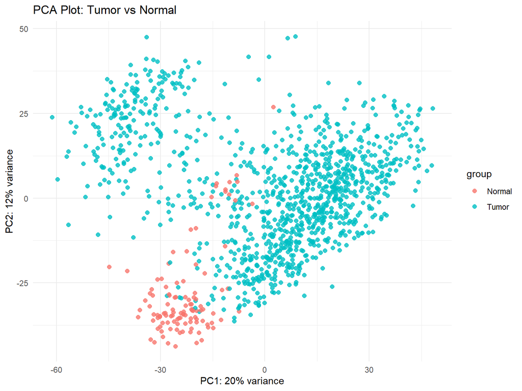

```r
percentVar <- round(100 * attr(pca_data, "percentVar"))

p_pca <- ggplot(pca_data, aes(PC1, PC2, color = group)) +
  geom_point(size = 2, alpha = 0.8) +
  xlab(paste0("PC1: ", percentVar[1], "% variance")) +
  ylab(paste0("PC2: ", percentVar[2], "% variance")) +
  ggtitle("PCA Plot: Tumor vs Normal") +
  theme_minimal()

print(p_pca)
```

# Heatmap of top differentially expressed genes

We visualize expression patterns of the top differentially expressed genes using a heatmap to observe clustering patterns between tumor and normal samples.

[figure not shown]

```r
library(pheatmap)

top50 <- res_df[order(res_df$padj), ][1:50, ]
top50_ids <- top50$gene_id

heatmap_matrix <- assay(vsd)[top50_ids, ]

annotation_col <- data.frame(
  Group = sample_metadata$group
)

rownames(annotation_col) <- colnames(heatmap_matrix)

pheatmap(
  heatmap_matrix,
  show_rownames = FALSE,
  annotation_col = annotation_col,
  scale = "row",
  clustering_distance_rows = "correlation",
  clustering_distance_cols = "correlation",
  main = "Heatmap of Top 50 Differentially Expressed Genes"
)
```

# Machine Learning Dataset Preparation

We prepare a machine learning dataset using the top differentially expressed genes as features to classify tumor and normal samples.

```r
library(caret)
top100 <- res_df[order(res_df$padj), ][1:100, ]
top100_ids <- top100$gene_id

ml_matrix <- t(assay(vsd)[top100_ids, ])

ml_data <- as.data.frame(ml_matrix)
ml_data$group <- sample_metadata$group

dim(ml_data)
```

```
## [1] 1224  101
```

```r
head(ml_data[, 1:6])
```

```
##                              ENSG00000099953.10 ENSG00000101605.13
## TCGA-BH-A18H-01A-11R-A12D-07           13.35649           6.121461
## TCGA-E2-A14P-01A-31R-A12D-07           13.34196           7.605246
## TCGA-AN-A04A-01A-21R-A034-07           16.16579           6.686720
## TCGA-5L-AAT1-01A-12R-A41B-07           16.79888           7.366242
## TCGA-GI-A2C8-11A-22R-A16F-07            8.27679          18.119414
## TCGA-AQ-A0Y5-01A-11R-A14M-07           15.33443           7.287192
##                              ENSG00000119927.14 ENSG00000123500.10
## TCGA-BH-A18H-01A-11R-A12D-07           9.385388          11.593803
## TCGA-E2-A14P-01A-31R-A12D-07          11.365203          10.738492
## TCGA-AN-A04A-01A-21R-A034-07           9.728269          14.889193
## TCGA-5L-AAT1-01A-12R-A41B-07           9.668639          12.320394
## TCGA-GI-A2C8-11A-22R-A16F-07          12.162838           5.437639
## TCGA-AQ-A0Y5-01A-11R-A14M-07          10.213665          13.954935
##                              ENSG00000117650.13 ENSG00000230838.1
## TCGA-BH-A18H-01A-11R-A12D-07           9.829021          7.732423
## TCGA-E2-A14P-01A-31R-A12D-07          10.776602          7.663767
## TCGA-AN-A04A-01A-21R-A034-07           9.739803          9.277499
## TCGA-5L-AAT1-01A-12R-A41B-07          10.366512          8.037020
## TCGA-GI-A2C8-11A-22R-A16F-07           5.630296          4.081340
## TCGA-AQ-A0Y5-01A-11R-A14M-07           8.403713         10.097696
```

# Split data for machine learning

We split the dataset into training and test sets so that the classifier can be trained on one subset and evaluated on unseen data.

```r
set.seed(123)

train_index <- createDataPartition(ml_data$group, p = 0.7, list = FALSE)

train_data <- ml_data[train_index, ]
test_data  <- ml_data[-train_index, ]

dim(train_data)
```

```
## [1] 858 101
```

```r
dim(test_data)
```

```
## [1] 366 101
```

```r
table(train_data$group)
```

```
##
## Normal  Tumor
##     80    778
```

```r
table(test_data$group)
```

```
##
## Normal  Tumor
##     33    333
```

# Random Forest classifier

We train a Random Forest machine learning model to classify tumor and normal samples using gene expression features.

# Convert outcome to factor

We convert the response variable to a factor so that Random Forest performs classification rather than regression.

```r
train_data$group <- as.factor(train_data$group)
test_data$group  <- as.factor(test_data$group)

str(train_data$group)
```

```
##  Factor w/ 2 levels "Normal","Tumor": 2 2 2 2 2 2 2 2 2 2 ...
```

```r
if (!requireNamespace("randomForest", quietly = TRUE)) {
  install.packages("randomForest", repos = "https://cloud.r-project.org")
}
library(randomForest)
```

# Train Random Forest classifier

We now train the Random Forest classifier using the training dataset after converting the response variable to a factor.

```r
rf_model <- randomForest(
  group ~ .,
  data = train_data,
  ntree = 500,
  importance = TRUE
)

rf_model
```

```
##
## Call:
##  randomForest(formula = group ~ ., data = train_data, ntree = 500,      importance = TRUE)
##                Type of random forest: classification
##                      Number of trees: 500
## No. of variables tried at each split: 10
##
##         OOB estimate of  error rate: 0.82%
## Confusion matrix:
##        Normal Tumor class.error
## Normal     76     4 0.050000000
## Tumor       3   775 0.003856041
```

# Model evaluation on test dataset

We evaluate the trained Random Forest classifier on the independent test dataset to assess predictive performance.

```r
rf_predictions <- predict(rf_model, newdata = test_data)

confusionMatrix(rf_predictions, test_data$group)
```

```
## Confusion Matrix and Statistics
##
##           Reference
## Prediction Normal Tumor
##     Normal     30     1
##     Tumor       3   332
##
##                Accuracy : 0.9891
##                  95% CI : (0.9723, 0.997)
##     No Information Rate : 0.9098
##     P-Value [Acc > NIR] : 7.602e-11
##
##                   Kappa : 0.9315
##
##  Mcnemar's Test P-Value : 0.6171
##
##             Sensitivity : 0.90909
##             Specificity : 0.99700
##          Pos Pred Value : 0.96774
##          Neg Pred Value : 0.99104
##              Prevalence : 0.09016
##          Detection Rate : 0.08197
##    Detection Prevalence : 0.08470
##       Balanced Accuracy : 0.95304
##
##        'Positive' Class : Normal
##
```

# Important genes from the Random Forest model

We examine variable importance from the Random Forest classifier to identify genes that contribute most to distinguishing tumor and normal samples.

```r
importance_scores <- importance(rf_model)

importance_df <- data.frame(
  gene = rownames(importance_scores),
  importance = importance_scores[, "MeanDecreaseGini"]
)

top_ml_genes <- importance_df[order(-importance_df$importance), ][1:20, ]

top_ml_genes
```

```
##                                  gene importance
## ENSG00000099953.10 ENSG00000099953.10  14.859908
## ENSG00000133800.9   ENSG00000133800.9   8.711564
## ENSG00000138640.15 ENSG00000138640.15   6.903589
## ENSG00000123500.10 ENSG00000123500.10   6.723718
## ENSG00000117650.13 ENSG00000117650.13   6.399452
## ENSG00000286214.1   ENSG00000286214.1   6.210277
## ENSG00000166803.14 ENSG00000166803.14   5.771174
## ENSG00000143228.13 ENSG00000143228.13   4.880545
## ENSG00000186642.16 ENSG00000186642.16   4.717253
## ENSG00000165028.12 ENSG00000165028.12   4.428677
## ENSG00000075702.18 ENSG00000075702.18   3.917210
## ENSG00000170509.12 ENSG00000170509.12   3.885922
## ENSG00000087586.18 ENSG00000087586.18   3.794338
## ENSG00000105974.13 ENSG00000105974.13   3.791843
## ENSG00000077152.11 ENSG00000077152.11   3.441307
## ENSG00000123243.15 ENSG00000123243.15   3.379953
## ENSG00000090889.12 ENSG00000090889.12   3.132750
## ENSG00000127564.17 ENSG00000127564.17   2.778132
## ENSG00000101605.13 ENSG00000101605.13   2.266980
## ENSG00000183856.11 ENSG00000183856.11   2.131800
```

# Machine learning–identified biomarker genes

We extracted the most important features from the Random Forest classifier.  
These genes contribute the most to distinguishing tumor and normal samples and may represent potential biomarkers or therapeutic targets.

```r
ml_gene_info <- gene_info[, c("gene_id", "gene_name")]
colnames(ml_gene_info) <- c("gene", "gene_symbol")

top_ml_genes_annotated <- merge(top_ml_genes, ml_gene_info, by = "gene")

top_ml_genes_annotated[, c("gene_symbol", "importance")]
```

```
##       gene_symbol importance
## 1           WDR62   3.917210
## 2           UBE2T   3.441307
## 3           AURKA   3.794338
## 4           KIF4A   3.132750
## 5           MMP11  14.859908
## 6           MYOM1   2.266980
## 7            CAV1   3.791843
## 8            NEK2   6.399452
## 9           ITIH5   3.379953
## 10        COL10A1   6.723718
## 11         PKMYT1   2.778132
## 12          LYVE1   8.711564
## 13         FAM13A   6.903589
## 14           NUF2   4.880545
## 15      NIPSNAP3B   4.428677
## 16          PCLAF   5.771174
## 17       HSD17B13   3.885922
## 18         IQGAP3   2.131800
## 19          PDE2A   4.717253
## 20 AUXG01000058.1   6.210277
```

# Machine learning biomarker genes

We visualized the most important genes identified by the Random Forest classifier.  
These genes contribute most strongly to distinguishing tumor and normal breast tissue samples.

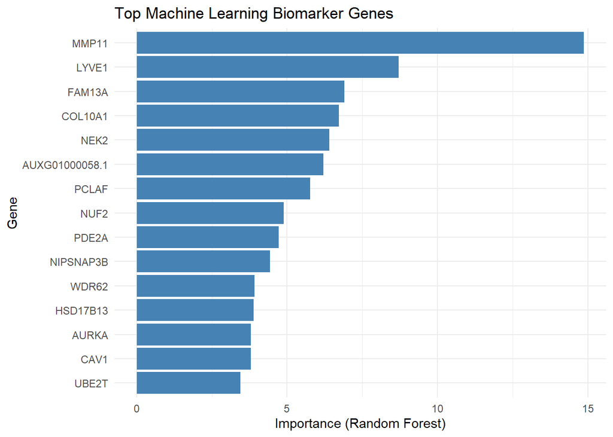

```r
library(ggplot2)

top_ml_genes_plot <- top_ml_genes_annotated[order(top_ml_genes_annotated$importance, decreasing = TRUE), ]

ggplot(top_ml_genes_plot[1:15, ], aes(x = reorder(gene_symbol, importance), y = importance)) +
  geom_bar(stat = "identity", fill = "steelblue") +
  coord_flip() +
  theme_minimal() +
  labs(
    title = "Top Machine Learning Biomarker Genes",
    x = "Gene",
    y = "Importance (Random Forest)"
  )
```

```r
ggsave(
  "../figures/ml_gene_importance.png",
  width = 8,
  height = 6,
  dpi = 300
)
```

# Candidate Therapeutic Targets in Breast Cancer

We integrated differential expression analysis, pathway enrichment results, and machine learning feature importance to identify candidate biomarker genes and potential therapeutic targets.

Several genes consistently appeared among the most significant features distinguishing tumor and normal samples. Notably, genes such as **MMP11, AURKA, NEK2, COL10A1, and CAV1** showed strong differential expression and high importance in the Random Forest classifier.

These genes are involved in biological processes relevant to cancer progression, including extracellular matrix remodeling, cell cycle regulation, and mitotic signaling.

For example:

- **MMP11** is a matrix metalloproteinase associated with tumor invasion and metastasis through extracellular matrix degradation.
- **AURKA (Aurora kinase A)** plays a critical role in mitotic spindle formation and has been widely studied as a therapeutic target in breast cancer.
- **NEK2** is a serine/threonine kinase involved in centrosome separation and chromosome segregation, frequently overexpressed in aggressive tumors.
- **COL10A1** is associated with extracellular matrix remodeling and has been reported as a biomarker in several cancers.
- **CAV1 (Caveolin-1)** is involved in cell signaling and tumor microenvironment regulation.

Together, these results highlight several candidate genes that may serve as potential biomarkers or therapeutic targets in breast cancer. Further experimental validation would be required to confirm their functional roles and clinical utility.